# Japan_Traveling

工海二 張在然

2018年10月17日

## 本報告旨在透過觀察一年間ptt日本旅遊板的文章，希望能整理出台灣遊客在不同時節間，赴日本旅遊的地點的選擇上有什麼不同

```r
##引入所需要的套件包
rm(list=ls(all.names = TRUE))
library(bitops)
library(httr)
library(RCurl)
library(XML)
library(tm)
library(NLP)
library(tmcn)
```

```r
library(jiebaRD)
library(jiebaR)
library(RColorBrewer)
library(wordcloud)
library(forcats)
library(ggplot2)
##文字清洗
toSpace <- content_transformer(function(x, pattern) {
  return (gsub(pattern, " ", x))
}
)
d.corpus <- Corpus( DirSource("./DATA") )
d.corpus <- tm_map(d.corpus, removePunctuation)
d.corpus <- tm_map(d.corpus, removeNumbers)

d.corpus <- tm_map(d.corpus, function(word) {
    gsub("[A-Za-z0-9]", "", word)
})
```

```r
mixseg = worker()
my.data <- read.csv("data.csv") ##做了一份日本都道府縣的生詞表，但是好像沒有起甚麼作用...
str(my.data)
```

```
## 'data.frame':    95 obs. of  1 variable:
##  $ words: Factor w/ 95 levels "?木縣","三重縣",..: 76 50 52 21 60 39 77 7 9 38 ...
```

```r
my.data$words <- as.character(my.data$words)
new_user_word(mixseg,my.data$words)
```

```
## [1] TRUE
```

```r
#一個爬蟲，上到日本關光局的旅遊景點表上把每個地點都爬下來當作新詞
library(rvest)
doc <- read_html("https://www.welcome2japan.tw/location/destinations/")
place <- doc %>% html_nodes("#box li a") %>% html_text()
new_user_word(mixseg,place)
```

```
## [1] TRUE
```

```r
#詞彙切割
jieba_tokenizer = function(d)
{
  unlist( segment(d[[1]], mixseg) )
}
seg = lapply(d.corpus, jieba_tokenizer)

count_token = function(d)
{
  as.data.frame(table(d))
}
tokens = lapply(seg, count_token)
```

```r
n = length(seg)
TDM = tokens[[1]]
colNames <- names(seg)
colNames <- gsub(".txt", "", colNames)
```

```r
 for( id in c(2:n) )
 {
  TDM = merge(TDM, tokens[[id]], by="d", all = TRUE)
  names(TDM) = c('d', colNames[1:id])
 }
TDM[is.na(TDM)] <- 0
TDM$d <- as.character(TDM$d)
TDM <- TDM[nchar(TDM$d)>1,] #篩掉字數小於一的詞
library(knitr)
kable(head(TDM))
```

|  | d | 01 | 02 | 03 | 04 | 05 | 06 | 07 | 08 | 09 | 10 | 11 | 12 |
| --- | --- | --- | --- | --- | --- | --- | --- | --- | --- | --- | --- | --- | --- |
| 40 | 一一 | 27 | 28 | 19 | 19 | 26 | 19 | 25 | 23 | 20 | 35 | 35 | 31 |
| 41 | 一丁 | 9 | 10 | 7 | 14 | 8 | 11 | 9 | 6 | 10 | 22 | 15 | 6 |
| 42 | 一丁點 | 2 | 0 | 0 | 0 | 0 | 2 | 2 | 0 | 1 | 3 | 0 | 0 |
| 43 | 一九 | 1 | 0 | 0 | 0 | 0 | 0 | 0 | 0 | 0 | 0 | 0 | 0 |
| 44 | 一二 | 6 | 6 | 5 | 4 | 5 | 2 | 7 | 4 | 4 | 8 | 5 | 3 |
| 45 | 一二三四五 | 1 | 0 | 0 | 0 | 1 | 0 | 0 | 0 | 2 | 0 | 0 | 0 |

```r
kable(tail(TDM))
```

|  | d | 01 | 02 | 03 | 04 | 05 | 06 | 07 | 08 | 09 | 10 | 11 | 12 |
| --- | --- | --- | --- | --- | --- | --- | --- | --- | --- | --- | --- | --- | --- |
| 223988 | 觀眾會 | 0 | 0 | 0 | 0 | 0 | 0 | 0 | 0 | 0 | 0 | 0 | 1 |
| 223989 | 觀都 | 0 | 0 | 0 | 0 | 0 | 0 | 0 | 0 | 0 | 0 | 0 | 1 |
| 223990 | 鑲飾 | 0 | 0 | 0 | 0 | 0 | 0 | 0 | 0 | 0 | 0 | 0 | 1 |
| 223991 | 鑽卡萬 | 0 | 0 | 0 | 0 | 0 | 0 | 0 | 0 | 0 | 0 | 0 | 1 |
| 223992 | 鑽近 | 0 | 0 | 0 | 0 | 0 | 0 | 0 | 0 | 0 | 0 | 0 | 1 |
| 223993 | 鸚哥 | 0 | 0 | 0 | 0 | 0 | 0 | 0 | 0 | 0 | 0 | 0 | 1 |

```r
tf <- apply(as.matrix(TDM[,2:(n+1)]), 2, sum)

library(Matrix)
idfCal <- function(word_doc)
{
  log2( n / nnzero(word_doc) )
}
idf <- apply(as.matrix(TDM[,2:(n+1)]), 1, idfCal)

doc.tfidf <- TDM
#Tf-Idf

tempY = matrix(rep(c(as.matrix(tf)), each = length(idf)), nrow = length(idf))
tempX = matrix(rep(c(as.matrix(idf)), each = length(tf)), ncol = length(tf), byrow = TRUE)
doc.tfidf[,2:(n+1)] <- (doc.tfidf[,2:(n+1)] / tempY) * tempX

stopLine = rowSums(doc.tfidf[,2:(n+1)])
delID = which(stopLine == 0)

kable(head(doc.tfidf[delID,1]))
```

| x |
| --- |
| 一一 |
| 一丁 |
| 一二 |
| 一人 |
| 一人份 |
| 一人約 |

```r
kable(tail(doc.tfidf[delID,1]))
```

| x |
| --- |
| 鑰匙圈 |
| 讚不絕口 |
| 讚賞 |
| 纜車 |
| 鑽石 |
| 鬱金香 |

```r
TopWords = data.frame()
for( id in c(1:n) )
{
  dayMax = order(doc.tfidf[,id+1], decreasing = TRUE)
  showResult = t(as.data.frame(doc.tfidf[dayMax[1:20],1]))
  TopWords = rbind(TopWords, showResult)
}
rownames(TopWords) = colnames(doc.tfidf)[2:(n+1)]
TopWords = droplevels(TopWords)
kable(TopWords)
```

|  | V1 | V2 | V3 | V4 | V5 | V6 | V7 | V8 | V9 | V10 | V11 | V12 | V13 | V14 | V15 | V16 | V17 | V18 | V19 | V20 |
| --- | --- | --- | --- | --- | --- | --- | --- | --- | --- | --- | --- | --- | --- | --- | --- | --- | --- | --- | --- | --- |
| 01 | 企劃書 | 遊日時 | 福娘 | 福袋 | 岩城 | 憩園 | 波佐見 | 勒索 | 畢業典禮 | 四價 | 僧堂 | 熊川宿 | 瓜割 | 滾過 | 換約 | 難不爛 | 田銀亭 | 丸岡城 | 忽左忽右 | 銀勝亭 |
| 02 | 鳥山 | 五龍 | 輪島 | 滑道 | 戶辦 | 加能 | 石打 | 畢格 | 西屋 | 玄奘 | 古山 | 庫洛 | 炸半雞 | 里鶴雅 | 食倒 | 養浩館 | 永住 | 炎神 | 丹頂鶴 | 水葉亭 |
| 03 | 鐵血 | 萩站 | 犬吠 | 熊谷 | 皇蛾 | 求湊 | 桃草 | 万葉亭 | 子市 | 白鸛 | 驛通 | 染井 | 龜戶 | 大牧 | 春之嵐 | 手魚 | 大腳 | 御藏島 | 湯治屋 | 犀鳥 |
| 04 | 麻疹 | 原谷苑 | 疫苗 | 抗體 | 接種 | 疾管署 | 兩劑 | 紫藤 | 生剝 | 化妝師 | 威林納 | 絲廠 | 大藤 | 剝館 | 造幣 | 龜戶 | 第推 | 湯治部 | 和裝 | 海津大崎 |
| 05 | 標案 | 真岡 | 夷隅 | 神和苑 | 透析 | 腎病 | 岸和田 | 山原 | 開標 | 合浦 | 病患 | 醫護人員 | 小到中雨 | 喜川 | 單根 | 益子 | 渦潮 | 岸壁 | 咬舌 | 護士服 |
| 06 | 要紙 | 阿嬤好 | 郵戳 | 刑場 | 收驚 | 阿胖 | 希少 | 阿爸 | 阿嬤超 | 土合 | 檔嗎 | 加勒比 | 扶輪社 | 透析 | 光伸 | 餘震 | 角田市 | 書道 | 氣囊 | 鴨台 |
| 07 | 白彩朝 | 鮮桃 | 吹割 | 生剝 | 佐多岬 | 早日康復 | 球團 | 彩香 | 化療 | 照吃 | 代稱 | 牧原 | 金守 | 阿明 | 城之島 | 海田 | 黑店 | 男鹿 | 薰衣草 | 阿莊 |
| 08 | 松月堂 | 父島 | 涼真 | 元分 | 萊克 | 宋家 | 盜圖 | 腦媽 | 吉慶 | 魚山人 | 仙壽 | 珊珊 | 會津檜 | 北極 | 小笠原諸島 | 具雜 | 輪島 | 玉置 | 折扣率 | 具足蟲 |
| 09 | 天佑 | 駐外 | 急難 | 認養 | 假新聞 | 外館 | 豬姐 | 徵位 | 代表處 | 中國大使館 | 保單 | 幽靈船 | 公路橋 | 餘震 | 山竹 | 球泉 | 派車 | 人津久 | 延保 | 假消息 |
| 10 | 小綿羊 | 遍路 | 仙溪園 | 山乃家 | 塗卡薩 | 大胖 | 霧多布 | 萩市 | 多羅 | 東灘 | 博香 | 掛籃 | 補寫 | 撬開 | 肥宅遊 | 青雲 | 味太助 | 屏幕 | 津山 | 立柱式 |
| 11 | 觀觀 | 池池 | 觀觀觀 | 原告 | 許太太 | 信玄餅 | 長老 | 湯元館 | 阿樂 | 酒款 | 資外 | 大胖 | 貓熊 | 七池 | 燕樂 | 會印 | 苦媽 | 沙翁 | 袋田 | 附島 |
| 12 | 青之島 | 御射 | 吉米 | 褲豬 | 鹿池 | 赤倉 | 阿川 | 八丈 | 幸樂 | 帝釋 | 赤尾館 | 合法經營 | 無膽 | 消防安全 | 東邦 | 室生寺 | 多明哥 | 主命 | 新年快樂 | 旁門 |

```r
TDM$d = as.character(TDM$d)
AllTop = as.data.frame( table(as.matrix(TopWords)) )
AllTop = AllTop[order(AllTop$Freq, decreasing = TRUE),]

kable(head(AllTop))
```

|  | Var1 | Freq |
| --- | --- | --- |
| 8 | 大胖 | 2 |
| 46 | 生剝 | 2 |
| 165 | 透析 | 2 |
| 214 | 輪島 | 2 |
| 216 | 餘震 | 2 |
| 223 | 龜戶 | 2 |

## 就實行的結果來說，可以參考的地方不多，主要問題應該出在於，不管是在哪個月分，台灣遊客對景點的選擇並沒有甚麼不同，導致不管是哪個景點，都會因為在每個月分的檔案中出現太多次反被篩選掉，再者，本報告統計資料量算是目前為止最為龐大的一次，導致垃圾資料也多出很多，但雖然沒辦法明顯的看到甚麼傾向，只要把觀察的範圍擴大，仍是可以看到一些蛛絲馬跡，像是一月有“福袋”這個詞，確實反映出每到日本新年，台灣旅客去日本百貨公司搶購福袋的現象;而九月的一連串大使館事件似乎也討論熱烈，看來tf-idf 比較會反映出某特定時段的事件。

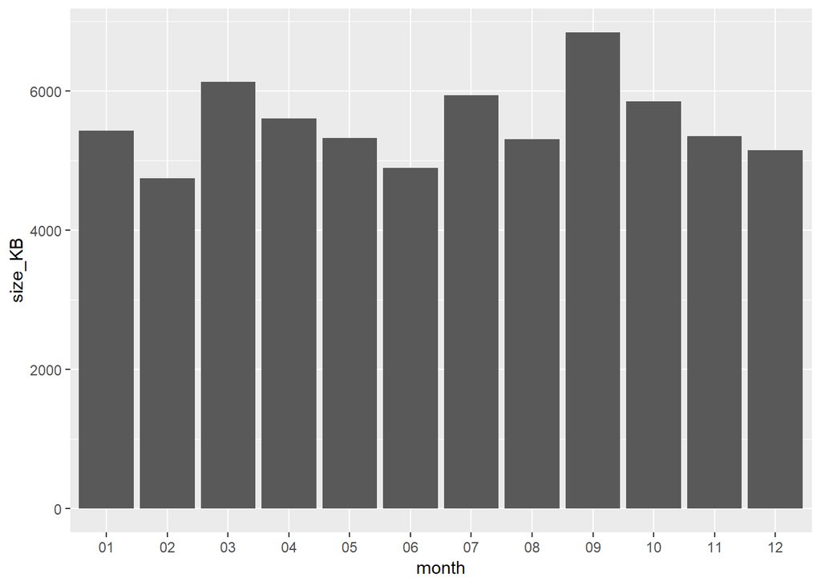

```r
filenames = as.array(paste0("./DATA/",colnames(doc.tfidf)[2:(n+1)],".txt"))
sizeResult = apply(filenames, 1, file.size) / 1024
showSize = data.frame(colnames(doc.tfidf)[2:(n+1)], sizeResult)
names(showSize) = c("month", "size_KB")
showSize$month <- fct_inorder(showSize$month)

ggplot(showSize, aes(x = month, y = size_KB)) + geom_bar(stat="identity")
```

## 上面為統計各個月分日旅版發文量之柱狀圖，可以發現九月份特別突出，回去比對資料後發現，其原因正來自由於九月日本一連串的天災事件，其中對大使館事件的討論也不少。

## 結論：本報告本來是要探討台灣人赴日旅遊會不會因為月份的差異而有所偏好，但是似乎沒有達到很好的成效，仔細觀察了一下詞頻矩陣，隨便一個日本景點在每個月裡可能都會有好幾百筆，這也導致無法透過tfidf進行良好的篩選(還是說有甚麼更好的辦法?)，而雖然結果不盡人意，卻仍可以從結果的一堆廢字中看到一些符合那個月的事件或是相關的東西，甚是欣慰。